# Investigating relationship between spheroid size and their differentiation status for the 3D multi-spheroid model using 3D-SiSP analytical method.

[Krittiyabhorn Kongtanawanich](https://github.com/KuchikiNamthip)

2025-02-25

# Overview of R analysis for investigating relationship between spheroid size and their differentiation status for the 3D multi-spheroid model.

Cancer stem cell (CSC) biology has many interesting angles to explore. Differentiation capability is one of the CSC properties where CSCs lose their stem cell potency and become non-CSCs. The differentiation status can also relate to other CSC characteristics.

In this case, we first explored the differentiation status of the spheroids from the sorted GFP-positive population (`POS`). The differentiation status of spheroid was defined as either “undifferentiation” or “differentiation” by using the background control spheroid (`mCMV`). We next explored the relationship between differentiation status of spheroid and spheroid size and presented it as a box plot.

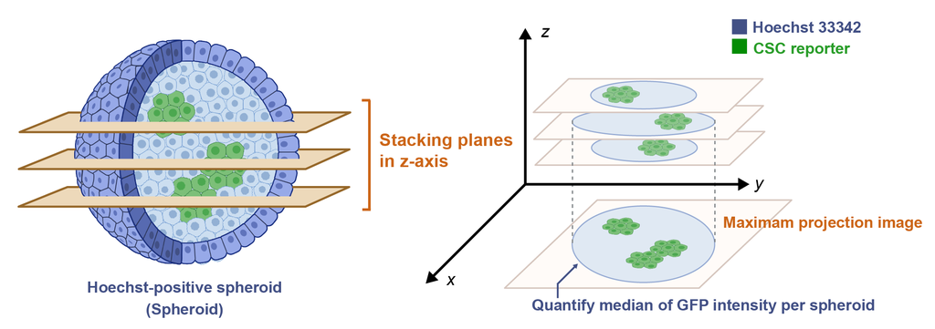

Figure 1: Image analysis of CSC content in the spheroid. Hoechst 33342: nuclear staining marker; CSC biosensor: cancer stem cell marker. (Created by BioRender.com / Mahidol University)

## 1. Analysis overview

#### Here, the analysis composed of 4 main sections below.

1. Section 1: Define information of the dataset.
2. Section 2: Load input data.
3. Section 3: Differentiation status analysis and visualization for the 3D multi-spheroids.
   - Part 3.1: Analysis
   - Part 3.2: Summary analysis
   - Part 3.3: Statistic test
   - Part 3.4: Data visualization
4. Section 4: Relationship between spheroid size and their differentiation status analysis and visualization for the 3D multi-spheroids.
   - Part 4.1: Analysis
   - Part 4.2: Summary analysis
   - Part 4.3: Statistic test
   - Part 4.4: Data visualization

## 2. Inputs

As an example, two of `.csv` files were provided [a set of example inputs](https://github.com/KuchikiNamthip/3D-SiSP/tree/main/3_Differentiation_Spheroid/input), where each `.csv` file contains information about the objects in the respective labeling.

1. `POS.csv` = data of all objects from a biosensor positive well.
2. `mCMV.csv` = data of all objects from a fluorescence background control well.

In each file contains 3 columns, which are described as below.

1. `BiosensorGroup` = CSC biosensor groups (`POS` or `mCMV`)
2. `Object_GFPint` = GFP intensity of each object
3. `Object_Area_um2` = Area of each object (μm²)

## Analysis for investigating relationship between spheroid size and their differentiation status for the 3D multi-spheroid model.

### Import R library

```r
library(dplyr)
library(ggplot2)
library(ggpubr)
library(rstatix)
```

## Section 1: Define information of the dataset.

To define information of the dataset.

1.1 Define working directory: `Output_Directory`  
1.2 Define input directory: `Input_Directory`  
1.3 Define the cell line name: `CellLine_Name`

```r
# Dataset example
  ## Output directory
    Output_Directory  <- 'path/to/directory'
    setwd(Output_Directory)

  ## Input directory
    Input_Directory   <- 'path/to/directory'

  CellLine_Name <- "CellLineX"
```

## Section 2: Load input data.

### Part 2.1: Import `mCMV` file (`mCMV.csv`)

The spheroid GFP intensities from the `mCMV` file will be used for the GFP cut-off calculation. This GFP cut-off will be further used for determining the spheroid differentiation status.

```r
    df.mCMV <- file.path(Input_Directory, "mCMV.csv")
    df.mCMV <- read.csv(df.mCMV)

    # Observe the `df.mCMV` data.
    head(df.mCMV)
```

```
##   BiosensorGroup Object_GFPint Object_Area_um2
## 1           mCMV      24.98866        472.0420
## 2           mCMV      34.61566      63133.8000
## 3           mCMV      21.55966         94.3376
## 4           mCMV      24.95266        130.5120
## 5           mCMV      24.93266         30.5001
## 6           mCMV      30.50766         79.4421
```

### Part 2.2: Import `POS` file (`POS.csv`)

The spheroid cultured by initial biosensor-positive cells; some of these spheroids were expected to spontaneously differentiate. Therefore, the `POS` file was imported for further analysis.

```r
    df.POS <- file.path(Input_Directory, "POS.csv")
    df.POS <- read.csv(df.POS)

    # Observe the `df.POS` data.
    head(df.POS)
```

```
##   BiosensorGroup Object_GFPint Object_Area_um2
## 1            POS      233.1773        33930.30
## 2            POS      143.4413        33412.20
## 3            POS      114.1873        33272.10
## 4            POS      243.1043        31942.50
## 5            POS      573.3143        31139.50
## 6            POS      363.1604        25636.05
```

## Section 3: Differentiation status analysis and visualization for the 3D multi-spheroids.

### Part 3.1: Analysis

#### Step 1: Define a GFP cut-off from `mCMV` data

For the GFP cut-off, GFP intensity from the highest 5% (`mCMV_CutOff`) of mCMV-created spheroids was used as the GFP intensity cut-off (`GFPint_CutOff`). The GFP cut-off can be customized by changing `mCMV_CutOff`.

```r
  # Define the mCMV cut-off (`mCMV_CutOff`)
    mCMV_CutOff <- 5

    print(paste("The highest", mCMV_CutOff,"% of mCMV-created spheroids was used as the GFP cut-off."))
```

```
## [1] "The highest 5 % of mCMV-created spheroids was used as the GFP cut-off."
```

#### Step 2: Find the GFP intensity cut-off (`GFPint_CutOff`) from the defined mCMV cut-off

```r
    # Find the total spheroid number in mCMV well
    Total_mCMVSpheroid  <- nrow(df.mCMV)

    # Find the spheroid number that will be cut according to `mCMV_CutOff`
    GFPint_CutPoint <- (Total_mCMVSpheroid*mCMV_CutOff)/100
    GFPint_CutPoint <- as.integer(GFPint_CutPoint) # round the number

      # if `GFPint_CutPoint` = 0, then change into 1
      GFPint_CutPoint <- ifelse(GFPint_CutPoint == 0,1, GFPint_CutPoint)

    CutPoint <- Total_mCMVSpheroid - GFPint_CutPoint

    # Sort spheroid in `df.mCMV` from low to high according to `Object_GFPint`
    Sorted_mCMV   <- sort(df.mCMV$Object_GFPint)
    Ranked_mCMV   <- rank(Sorted_mCMV)
    GFPint_CutOff <- Sorted_mCMV[Ranked_mCMV[CutPoint]]

    # The GFP intensity cut-off  from the defined mCMV cut-off
    GFPint_CutOff
```

```
## [1] 90.18166
```

```r
    print(paste("The spheroids with GFP intensity above", GFPint_CutOff,
                "will be called 'Undifferentiated spheroid'"))
```

```
## [1] "The spheroids with GFP intensity above 90.18166242 will be called 'Undifferentiated spheroid'"
```

#### Step 3: Identify differentiation status of the spheroids

If the spheroid GFP intensity is greater than `GFPint_CutOff`, the differentiation status will be defined as “Undifferentiated”. Conversely, if the spheroid GFP intensity is lower than `GFPint_CutOff`, the status will be defined as “Differentiated”.

```r
  df.POS$Status <- ifelse(df.POS$Object_GFPint >= GFPint_CutOff, "Undifferentiated", "Differentiated")

  # Calculate log10 of spheroid GFP intensity
  df.POS <- mutate(df.POS, log10_GFPint = log10(Object_GFPint))

  # Observe the `df.POS` data
  head(df.POS)
```

```
##   BiosensorGroup Object_GFPint Object_Area_um2           Status log10_GFPint
## 1            POS      233.1773        33930.30 Undifferentiated     2.367686
## 2            POS      143.4413        33412.20 Undifferentiated     2.156674
## 3            POS      114.1873        33272.10 Undifferentiated     2.057618
## 4            POS      243.1043        31942.50 Undifferentiated     2.385793
## 5            POS      573.3143        31139.50 Undifferentiated     2.758393
## 6            POS      363.1604        25636.05 Undifferentiated     2.560098
```

#### Step 4: Calculate percentage of undifferentiated spheroids in the whole spheroids.

```r
  # Count undifferentiated spheroids from `df.POS`
  UndiffSpheroid <- sum(df.POS$Status == "Undifferentiated")

  # Count total spheroids from `df.POS`
  TotalSpheroid <- nrow(df.POS)

  # Calculate percentage of undifferentiated spheroids in the whole spheroids.
  Percent_UndiffSpheroid <- (UndiffSpheroid/TotalSpheroid) * 100 #percentage of SORE6pos

  print(paste0("Spheroids with GFP intensity higher than ", GFPint_CutOff,
              " (background control (mCMV) cut-off = ", mCMV_CutOff, "%) will be counted as undifferentiated spheroid, ",
              "therefore undifferentiated spheroid from the POS well = ", Percent_UndiffSpheroid, "%, "
              ))
```

```
## [1] "Spheroids with GFP intensity higher than 90.18166242 (background control (mCMV) cut-off = 5%) will be counted as undifferentiated spheroid, therefore undifferentiated spheroid from the POS well = 30.1115241635688%, "
```

### Part 3.2: Summary analysis

```r
  Summary_SpheroidGFP <- df.POS %>%
    group_by(Status) %>%
    summarise_at(vars(log10_GFPint),
                 list(Median_SpheroidGFP = median,
                      SD_SpheroidGFP  = sd))

  # Write the `Summary_SpheroidGFP` into a `.csv` file.
   write.csv(Summary_SpheroidGFP,
            paste0("Summary_SpheroidGFP.csv"), row.names = FALSE)

   print(paste0("The .csv file was written as 'Summary_SpheroidGFP.csv'."))
```

```
## [1] "The .csv file was written as 'Summary_SpheroidGFP.csv'."
```

Observe the `Summary_SpheroidGFP` data

```r
  Summary_SpheroidGFP
```

```
## # A tibble: 2 × 3
##   Status           Median_SpheroidGFP SD_SpheroidGFP
##   <chr>                         <dbl>          <dbl>
## 1 Differentiated                 1.55          0.347
## 2 Undifferentiated               2.22          0.243
```

### Part 3.3: Statistic test

#### Step 1: Normality test

To determine whether the data follows a normal distribution, the normality test should be performed.

```r
  shapiro.test(df.POS$log10_GFPint)
```

```
##
##  Shapiro-Wilk normality test
##
## data:  df.POS$log10_GFPint
## W = 0.98793, p-value = 0.02384
```

For the example dataset, the result showed that the data do not follow a normal distribution.

#### Step 2: Statistical test

According to the non-normal distribution of the data, the Wilcoxon rank-sum test was used for statistical testing by comparing the GFP intensity of the spheroids between undifferentiated and differentiated group.

If your data follows a normal distribution, a parametric test like the “T-test” should be used instead.  
Here, we also provide the choice of statistical tests as shown below.

```r
  # T-test
    Stat_SpheroidStatus_Ttest <- compare_means(log10_GFPint ~ Status,
                                          data     = df.POS,
                                          method   = "t.test"
                                        )

  # Wilcoxon rank-sum test
    Stat_SpheroidStatus_Wilcox <- compare_means(log10_GFPint ~ Status,
                                          data     = df.POS,
                                          method   = "wilcox.test"
                                        )

  # Write the `Stat_ObjectArea` into a `.csv` file.
    write.csv(Stat_SpheroidStatus_Wilcox,
                paste0(CellLine_Name, "_Stat_SpheroidStatus.csv"), row.names = FALSE)

    print(paste0("Statistical test of the differentiation status of the spheroids was written as 'Stat_SpheroidStatus.csv'"))
```

```
## [1] "Statistical test of the differentiation status of the spheroids was written as 'Stat_SpheroidStatus.csv'"
```

Observe the `Stat_SpheroidStatus_Wilcox` data.

```r
 Stat_SpheroidStatus_Wilcox
```

```
## # A tibble: 1 × 8
##   .y.          group1          group2        p    p.adj p.format p.signif method
##   <chr>        <chr>           <chr>     <dbl>    <dbl> <chr>    <chr>    <chr>
## 1 log10_GFPint Undifferentiat… Diffe… 1.12e-38 1.10e-38 <2e-16   ****     Wilco…
```

### Part 3.4: Data visualization

```
## [1] "The .png file was saved as 'SpheroidGFP_Plot.png'"
```

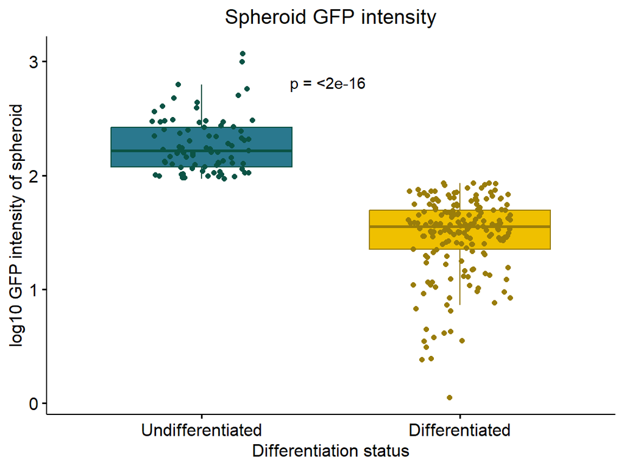

```r
  # Convert the variable `Status` from character to factor
  df.POS$Status <- factor(df.POS$Status, level = c("Undifferentiated", "Differentiated"))

  # Box plot
  SpheroidStatus_Plot <- ggboxplot(df.POS, x = "Status", y = "log10_GFPint",
                                          color = "Status", fill = "Status", add = "jitter")+
                            scale_color_manual(values = c("#0B5345", "#9A7D0A")) +
                            scale_fill_manual(values = c("#2A788EFF", "#EFC000FF")) +
                            labs(x = "Differentiation status",
                                 y = "log10 GFP intensity of spheroid",
                                 title = "Spheroid GFP intensity") +
                            theme(plot.title = element_text(hjust = 0.5)) +
                            guides(fill = guide_legend(title = NULL)) +
                            stat_compare_means(label = "p.format", method = "wilcox.test",
                                               label.x.npc = 0.4, label.y.npc =0.9)+
                            theme(legend.position = "none")

  # Save the plot as a `.png` file.
  ggsave('SpheroidGFP_Plot.png', width = 3, height = 5, dpi = 300, units = "in")

  print(paste0("The .png file was saved as 'SpheroidGFP_Plot.png'"))
```

Figure 2: Spheroid GFP intensity analysis of undifferentiated and differentiated spheroids.

## Section 4: Relationship between spheroid size and their differentiation status analysis and visualization for the 3D multi-spheroids.

### Part 4.1: Analysis

```r
  df.POS <- mutate(df.POS, log10_SpheroidArea = log10(Object_Area_um2))
```

### Part 4.2: Summary analysis

```r
  Summary_SpheroidArea <- df.POS %>%
    group_by(Status) %>%
    summarise_at(vars(log10_SpheroidArea),
                 list(Median_SpheroidArea = median,
                      SD_SpheroidArea   = sd))

  # Write the `Summary_SpheroidArea` into a `.csv` file.
   write.csv(Summary_SpheroidArea,
            paste0("Summary_SpheroidArea.csv"), row.names = FALSE)

   print(paste0("The .csv file was written as 'Summary_SpheroidArea.csv'."))
```

```
## [1] "The .csv file was written as 'Summary_SpheroidArea.csv'."
```

Observe the `Summary_SpheroidArea` data

```r
  Summary_SpheroidArea
```

```
## # A tibble: 2 × 3
##   Status           Median_SpheroidArea SD_SpheroidArea
##   <fct>                          <dbl>           <dbl>
## 1 Undifferentiated                3.73           0.904
## 2 Differentiated                  2.27           0.782
```

### Part 4.3: Statistic test

#### Step 1: Normality test

To determine whether the data follows a normal distribution, the normality test should be performed.

```r
  shapiro.test(df.POS$log10_SpheroidArea)
```

```
##
##  Shapiro-Wilk normality test
##
## data:  df.POS$log10_SpheroidArea
## W = 0.93704, p-value = 2.658e-09
```

For the example dataset, the result showed that the data do not follow a normal distribution.

#### Step 2: Statistical test

According to the non-normal distribution of the data, the Wilcoxon rank-sum test was used for statistical testing by comparing the spheroid area between undifferentiated and differentiated spheroids.

If your data follows a normal distribution, a parametric test like the “T-test” should be used instead.  
Here, we also provide the choice of statistical tests as shown below.

```r
  # T-test
    Stat_SpheroidArea_Ttest <- compare_means(log10_SpheroidArea ~ Status,
                                          data     = df.POS,
                                          method   = "t.test"
                                        )

  # Wilcoxon rank-sum test
    Stat_SpheroidArea_Wilcox <- compare_means(log10_SpheroidArea ~ Status,
                                          data     = df.POS,
                                          method   = "wilcox.test"
                                        )

  # Write the `Stat_ObjectArea` into a `.csv` file.
    write.csv(Stat_SpheroidArea_Wilcox,
                paste0(CellLine_Name, "_Stat_SpheroidArea.csv"), row.names = FALSE)

    print(paste0("Statistical test of spheroid area was written as 'Stat_SpheroidArea.csv'"))
```

```
## [1] "Statistical test of spheroid area was written as 'Stat_SpheroidArea.csv'"
```

Observe the `Stat_SpheroidArea_Wilcox` data.

```r
 Stat_SpheroidArea_Wilcox
```

```
## # A tibble: 1 × 8
##   .y.                group1    group2        p    p.adj p.format p.signif method
##   <chr>              <chr>     <chr>     <dbl>    <dbl> <chr>    <chr>    <chr>
## 1 log10_SpheroidArea Undiffer… Diffe… 1.09e-15 1.10e-15 1.1e-15  ****     Wilco…
```

### Part 4.4: Data visualization

```
## [1] "The .png file was saved as 'SpheroidArea_Plot.png'"
```

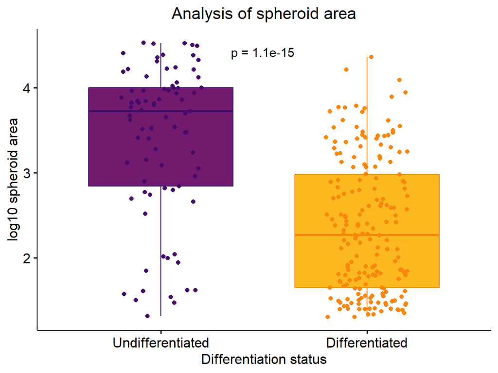

```r
  SpheroidArea_Plot <- ggboxplot(df.POS, x = "Status", y = "log10_SpheroidArea",
                                        color = "Status", fill = "Status", add = "jitter")+
                          scale_color_manual(values = c("#460B6AFF", "#F8870EFF")) +
                          scale_fill_manual(values = c("#711A6EFF", "#FBB91FFF")) +
                          labs(x = "Differentiation status",
                               y = "log10 spheroid area",
                               title = "Analysis of spheroid area") +
                          theme(plot.title = element_text(hjust = 0.5)) +
                          guides(fill = guide_legend(title = NULL)) +
                          stat_compare_means(label = "p.format", method = "wilcox.test",
                                             label.x.npc = 0.4, label.y.npc = 0.95)+
                          theme(legend.position = "none")

  # Save the plot as a `.png` file.
  ggsave('SpheroidArea_Plot.png', width = 3, height = 5, dpi = 300, units = "in")

  print(paste0("The .png file was saved as 'SpheroidArea_Plot.png'"))
```

Figure 3: Spheroid area analysis of undifferentiated and differentiated spheroids.